# Monitoring scheme for biotic habitat quality of Natura 2000 habitat types in Flanders, Belgium

Revision of the monitoring design

Westra

Toon.Westra@inbo.be

Oosterlynck

# Acknowledgement

Dankwoord

# Abstract

Abstract

# Samenvatting

Samenvatting

# 1 Introduction

# 2 Information needs

## 2.1 European level

Every six years each EU member state has to report on the conservation status of the European protected habitat types listed in Annex 1 of the Habitat Directive.

The conservation status of habitat types should be assessed per biogeographical region is determined by four criteria (DG Environment 2017):

- **Range**
- **Area**
- **Specific structure and functions (including typical species)**
- **Future prospects**

Each criteria is evaluated according to the evaluation matrix specified in the reporting guidelines in DG Environment (2017).

The conservation status of **specific structure and functions (including typical species)** is assessed as follows:

- **Favourable**: Structures and functions (including typical species) in good condition and no significant deteriorations / pressures
- **Unfavourable - Bad**: More than 25% of the area is unfavourable as regards its specific structures and functions (including typical species)
- **Unfavourable – Inadequate**: Any other combination
- **Unknown**: No or insufficient reliable information available

The guidelines (DG Environment 2017) stress the importance of trend information as trends are decisive for the assessment of conservation status since usually only stable or increasing trends can result in an overall favourable conservation status (FCS) conclusion. It is advised that more attention should be paid to the methodology of monitoring schemes to improve the quality of trend information. A short-term trend is considered as the trend over two reporting cycles (12 years). The recommended period for assessing longer-term trends is four reporting cycles (24 years).

## 2.2 Regional level

Flanders is situated in the northern part of Belgium and is largely within the Atlantic biogeographical region. INBO is responsible for the assessment of the CS of habitat types on the scale of Flanders. The results of Flanders are than integrated with the results of the the Walloon and Brussels Capital region to assess the CS of habitat types on the scale of Belgium per biogeographical region. This integrated assessment is reported to the European Commission.

The methodology that is used by INBO to evaluate the CS of the criteria specific structure and functions (including typical species) is based on the general guidelines by (DG Environment 2017) and is described in more detail in (Paelinckx et al. 2019). It requires following information per habitat type:

- the status and trend of the percentage of the habitat area that is in a good local condition as regards its specific structures and functions
- habitat typical species
- landscape ecological coherence
- pressures and threats

The monitoring scheme for biotic habitat quality (MHQ) supports the assessment of the habitat area that is in a good local condition (as regards its specific structures and functions). As the name of the monitoring scheme suggest, we use the term ‘biotic habitat quality’ to refer to the specific structure and functions of the habitat. Further in this report we will only focus on this part of the information needs.

In Flanders 46 habitat types occur and several of these habitat types are subdivided into habitat subtypes (Appendix A). Nature policy in Flanders also requires information on habitat quality for these habitat subtypes. However, this information has a lower priority and therefore a lower precision (compared to the habitat main types) is acceptable.

# 3 Overview of MHQ

## 3.1 Monitoring target

Based on the information needs we can summarize the main targets of MHQ as follows:

- the habitat quality status per habitat type and per habitat subtype
  - what is the percentage of the habitat area that is in good/bad condition?
  - is this percentage of habitat in bad condition higher or lower than 25%?
- the habitat quality short-term (12 years) and long-term (24 years) trend per habitat type and per habitat subtype
  - what is the trend of the habitat area that is in a good/bad condition?
  - is the habitat quality stable, improving or deteriorating?

The original design of MHQ (Westra et al. 2014) was mainly based on the target for the status of habitat quality. In this report we will evaluate how the design can be modified to better meet the monitoring target for the trend in habitat quality. We will evaluate different scenario’s based on sample size calculations for status and trend in habitat quality. But first we resume how the habitat quality is defined and what is measured in the field.

## 3.2 Biotic habitat quality indicators

The report of (Oosterlynck et al. 2020) provides a series of criteria and indicators to define the favourable conservation status of the habitat quality for 44 habitattypes and 41 habitatsubtypes, that occur in Flanders. Different types of indicators are included that are related to:

- vegetation composition
- vegetation structure
- disturbances
- spatial connectivity

## 3.3 Field measurements

- vegetation composition: presence and cover of all plant species per vegetation layer
- structure variables: measurement of variables related to vegetation structure

The spatial scale at which these variables are measured, depends on the habitat type is shown in 3.1. Note that these measurements do not allow the evaluation of the indicators related to spatial connectivity.

Tabel 3.1: Spatial scale at which the vegetation composition and structure variables are measured

| category | habitat type | vegetation composition | structure variables |
| --- | --- | --- | --- |
| terrestrial | forest | 9m x 9m square plot | 18m diameter circle plot |
|  | open | 3m x 3m square plot | 18m diameter circle plot |
| aquatic | river | 100m river segment | 100m river segment |
|  | standing water | entire water body | entire water body |

## 3.4 Sample size calculations

Sample size calculations provide an insight in the relationship between sample size and the minimal detectable effect size for a given significance level $\alpha$ and power $\pi$. $\alpha$ is the probability of a type I error, i.e. the probability of concluding that there is no effect based on a the sample, when in reality there is an effect. $\pi$ is the probability to detect an effect based on a sample, when the effect also exists in reality.

The original sample size of the monitoring scheme is based on sample size calculations for the status of the habitat quality (Westra et al. 2014). We will first reproduce the sample size calculations in (Westra et al. 2014). Next we will also perform a sample size calculation for the trend in habitat quality.

As in (Westra et al. 2014), we will choose a power $\pi$ of 0.80 and a significance level $\alpha$ of 0.05.

### 3.4.1 Habitat quality status

#### 3.4.1.1 Minimal detectable difference between the proportion of habitat with bad quality and the 25%-threshold

The quality of a habitat type is unfavourable (on a regional scale) when more than 25% of the habitat area has a bad quality (on a local scale). Here we want to determine the minimal detectable difference from the 25%-threshold.

Figure 3.1 and Table 3.2 show the results of the sample size calculations. The results can be interpreted as follows. When in reality less than 16.3 % of the habitat has a bad quality, we will be able to conclude that the habitat proportion with a bad quality is significantly lower than the 25%-threshold when we have sample size of 170 (with $\pi = 0.80$ and $\alpha = 0.05$). Hence, the minimal detectable difference is 8,7 %. Similarly, when in reality more than 34,8 % of the habitat has a bad condition, we will be able to conclude that the habitat proportion with a bad quality is significantly higher than the 25%-threshold. When the habitat proportion with a bad quality is between 16,3 % and 34,8 %, a sample size of 170 will not allow us to detect a difference from the 25%-threshold.

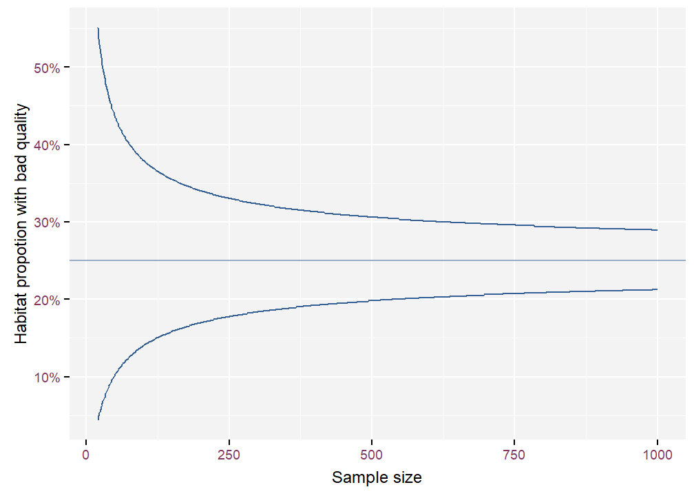

Figuur 3.1: Relationship between sample size and minimal detectable difference

Tabel 3.2: Minimal detectable effect as a function of the sample size with $\alpha = 0.05$ and $\pi = 0.80$

| sample size | favourable | unfavourable | Minimal detectable effect lower | Minimal detectable effect higher |
| --- | --- | --- | --- | --- |
| 40 | < 8.9 % | > 46 % | -16.1 | 21.0 |
| 80 | < 12.9 % | > 39.6 % | -12.1 | 14.6 |
| 170 | < 16.3 % | > 34.8 % | -8.7 | 9.8 |
| 400 | < 19.2 % | > 31.3 % | -5.8 | 6.3 |
| 1000 | < 21.3 % | > 28.9 % | -3.7 | 3.9 |

#### 3.4.1.2 Comparison with results of the 2019 habitat reporting

In Figure 3.2 we show the estimated habitat proportions with bad quality as reported in 2019. This reporting was based on the plots that where measured in the period 2014 - 2018. This means that only a subset of the total sample size was measured at that time, as the total monitoring cycle was 12 years. Only for the more common forest habitat types we already reached the total sample size, as we could make use of the measurements of the Flemish Forest Inventory.

The habitat types are represented by the habitat code and the colour corresponds with the habitat quality evaluation: favourable, unknown or unfavourable. For many habitat types we can already conclude that the quality is unfavourable, even with a sample size much smaller than 170. This is because in many cases the habitat proportion with bad quality is much higher than the 25%-threshold and such large differences can be detected with sufficient power based on smaller sample sizes, as can be seen in Figure 3.1 and Table 3.2. Only for two habitat types (2160 and 2190) we need a higher precision in order to conclude if the proportion with bad quality is higher or lower than the 25%-threshold.

In the coming years, it will be more relevant for nature policy to get information on the trend of habitat quality (does the quality of the unfavourable habitat types improve?) than to invest in a higher precision of the status of habitat quality. In other words, it will probably be better to shorten the original monitoring cycle and to start revisiting the measured plots sooner as planned. This requires an adjustment of the monitoring design. Therefore we will also perform sample size calculations for trends in habitat quality. This way we can find a good balance between the precision of the habitat quality status and the precision of the trend.

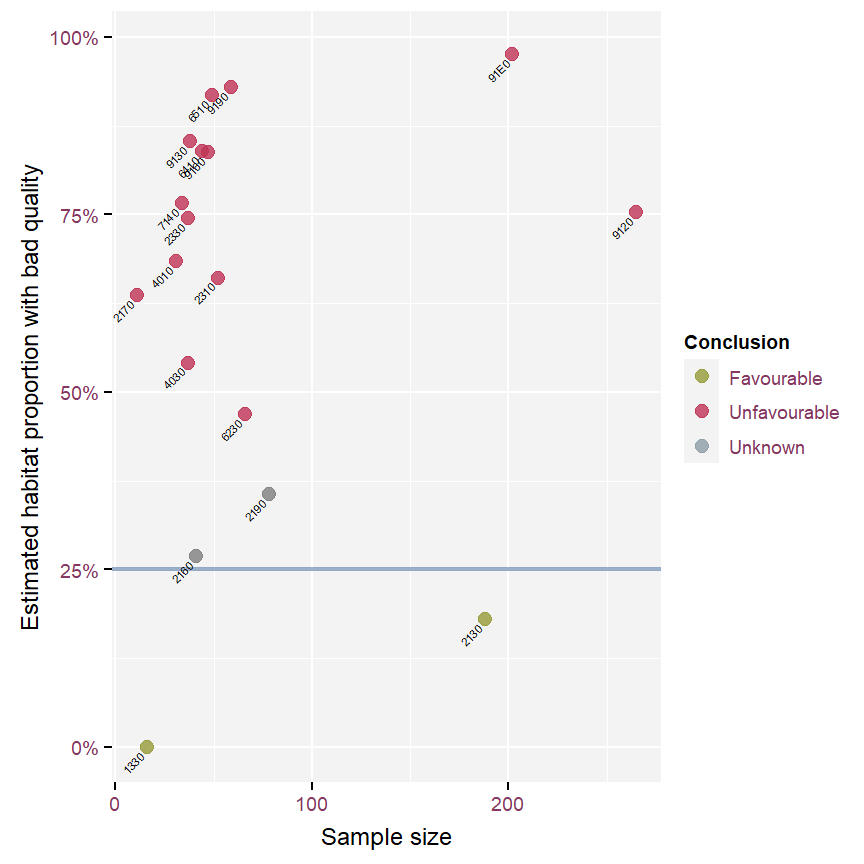

Figuur 3.2: Results of the habitat reporting

### 3.4.2 Trends in habitat quality

#### 3.4.2.1 Difference between proportions

To determine the detectable difference in habitat proportions with bad quality between two points in time, we apply the McNemar test (Chow SC, Shao J, Wang H. 2003) using the function `McNemar.Test` in the R package TrialSize (G.Zhang 2020).

The habitat monitoring scheme consists of permanent plots resulting in paired observations. When the habitat quality in a plot is measured at two time points $t_1$ and $t_2$, we can have one of following combinations.

| $t_1$ | $t_2$ bad | $t_2$ good |
| --- | --- | --- |
| bad | no change | bad -> good |
| good | good -> bad | no change |

The difference in the proportion with bad quality between $t_1$ and $t_2$ corresponds with the difference in the habitat area that evolves from bad to good ($hab_{01}$) and the area that evolves from good to bad ($hab_{10}$). Figure 3.3 shows the minimal detectable increase/decrease in proportion with bad quality as a function of the sample size and the *dynamics* of the habitat type. We define the dynamics as a measure for the amount of habitat for which the quality changes given a total net change in habitat quality:

$$\frac{hab_{01} + hab_{10}}{| hab_{01} - hab_{10}|}$$

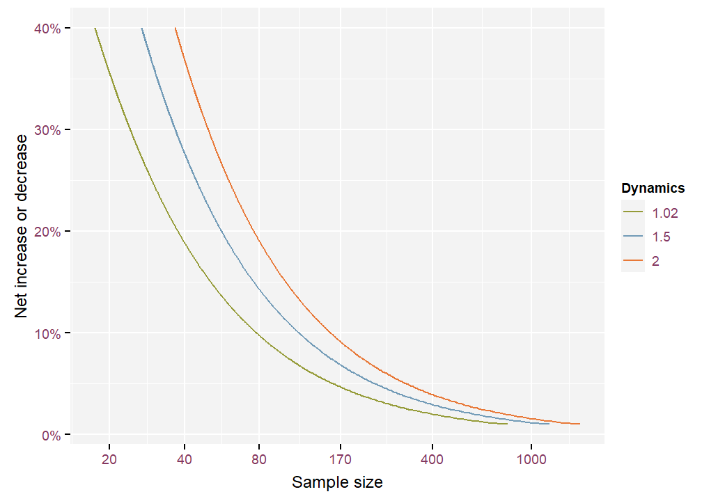

Figuur 3.3: Minimal detectable effect as a function of sample size and the dynamics with $\alpha$ = 0.05 and $\pi$ = 0.80

Tabel 3.3: Minimal detectable difference as a function of sample size and dynamics (low dynamics = 1.02, medium dynamics = 1.5 and high dynamics = 2) with $\alpha$ = 0.05 and $\pi$ = 0.80

| sample size | net decrease or increase (%) low dynamics | net decrease or increase (%) medium dynamics | net decrease or increase (%) high dynamics |
| --- | --- | --- | --- |
| 40 | 18.9 | 27.7 | 36.9 |
| 80 | 9.7 | 14.3 | 19.1 |
| 170 | 4.7 | 6.8 | 9.1 |
| 400 | 2.0 | 2.9 | 3.9 |

It is hard to predict which values for the dynamics can be expected for the different habitat types. However, the data of the Flemish Forest Inventory might give us an idea about the forest habitat types. Table 3.4 shows the number of paired observations and the number of plots that evolve from bad to good quality ($n_{01}$) and from good to bad quality ($n_{10}$). For habitat type 9120 the dynamics are equal to 2.2. For the other forest habitat types we van not get a reliable estimate of the dynamics as the sample size is to low or there is no net difference.

Tabel 3.4: Inschating van de dynamics van de boshabitattypen op basis van de gegevens van de Vlaamse bosinventarisatie

| habitat type | $n_{paired}$ | $n_{01}$ | $n_{10}$ | dynamics |
| --- | --- | --- | --- | --- |
| 9120 | 115 | 3 | 8 | 2.2 |
| 9130 | 13 | 1 | 0 | 1.0 |
| 9160 | 19 | 1 | 0 | 1.0 |
| 9190 | 17 | 0 | 0 |  |
| 91E0 | 43 | 3 | 3 |  |

#### 3.4.2.2 Differences between habitat quality indicators

Continuous, discrete or categorical variables that are a measure for habitat quality are more sensitive to changes than a binary variable (good or bad habitat quality). Example of such variables are:

- values of habitat quality indicators as listed in (Oosterlynck et al. 2020)
- the proportion of habitat quality indicators for a certain habitat type that are favourable
- a continuous habitat quality index based on the distance to the threshold values for the different habitat quality indicators of a habitat type

##### 3.4.2.2.1 Sample size calculation for continous variables

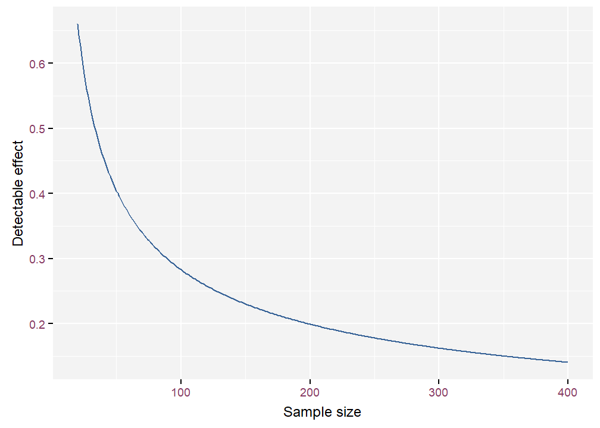

Figuur 3.4: Detectable effetc size ($d$) as a function of the sample size with $\pi = 0.8$

Tabel 3.5: Detectable effect as a function of sample size and significance level with $\pi=0.80$

| Sample size | Detectable effect |
| --- | --- |
| 40 | 0.454 |
| 80 | 0.317 |
| 170 | 0.216 |
| 400 | 0.140 |

The detectable effect is a quite abstract measure and not so easy to interpret. To make things more specific, in Figure 3.5 and Table 3.6 we show a variable expressed as a percentage with values between 0 and 100. This could be for example the proportion of habitat indicators that are favourable on a certain location or the vegetation cover of a certain species group. With a sample size of 170 kunnen we can detect a mean difference of approximately 1 to 3 % depending on the standard deviation of the difference. With a sample size of 80 this is approximately 1.5 to 5 %.

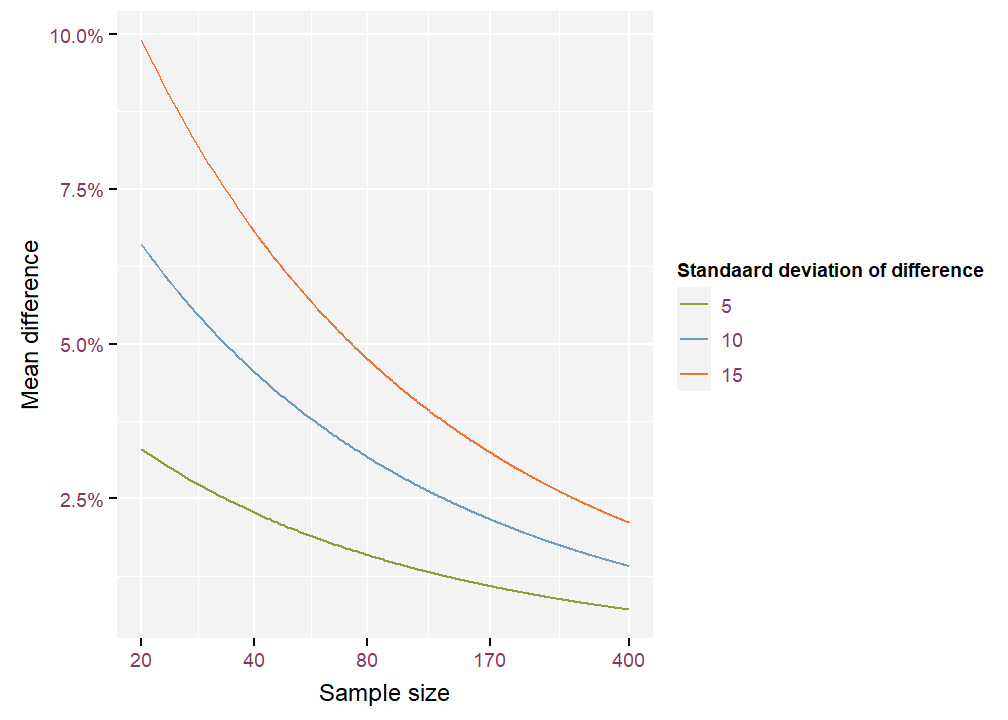

Figuur 3.5: Detectable mean difference as a function of sample size and standard deviation of the difference for a variable that is expressed as a percentage with $\alpha=0.05$ and $\pi=0.80$

Tabel 3.6: Detectable mean difference (%) as a function of sample size and standard deviation of the difference with $\alpha=0.05$ and $\pi=0.80$

| sample size | Standaard deviation of difference 5 | Standaard deviation of difference 10 | Standaard deviation of difference 15 |
| --- | --- | --- | --- |
| 40 | 2.3 | 4.5 | 6.8 |
| 80 | 1.6 | 3.2 | 4.8 |
| 170 | 1.1 | 2.2 | 3.2 |
| 400 | 0.7 | 1.4 | 2.1 |

We will further explore the data of the Flemish Forest Inventory to get a rough idea on which standard deviation of differences we can expect for habitat quality indicators.

##### 3.4.2.2.2 Example 1: trend in proportion of favourable indicators for forest habitat types

The Forest Inventory data allows the calculation and evaluation of most habitat quality indicators defined in (Oosterlynck et al. 2020) for the plots that are located in a forest habitat types. Based on this, we can determine the proportion of the total number of indicators that are favourable per plot. Figure 3.6 shows this proportion for the plots that were measured in both the first period (1997-1998) and the second period (2009-2018) of the Flemish Forest Inventory.

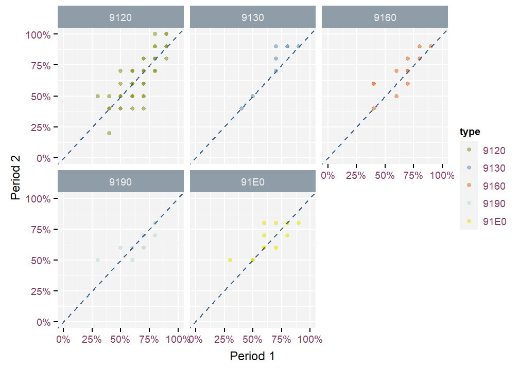

Figuur 3.6: Proportion of habitat quality indicators that are favourable per plot, for both periods of the Flemish Forest Inventory

| habitat type | sample size | mean difference | standard devitation of difference | d | p-value | conclusion |
| --- | --- | --- | --- | --- | --- | --- |
| 9120 | 60 | -1.17 | 10.43 | -0.112 | 0.38976 | unknown |
| 9130 | 8 | 6.25 | 7.44 | 0.840 | 0.04917 | increase |
| 9160 | 13 | 3.85 | 9.61 | 0.401 | 0.17451 | unknown |
| 9190 | 13 | -0.77 | 8.62 | -0.089 | 0.75326 | unknown |
| 91E0 | 15 | 2.00 | 9.41 | 0.213 | 0.42428 | unknown |
| 91xx | 109 | 0.46 | 9.94 | 0.046 | 0.63102 | unknown |

| sd of difference | sample size | d | detectable difference |
| --- | --- | --- | --- |
| 7 - 11 | 40 | 0.45 | 3.1 - 5 |
|  | 80 | 0.32 | 2.2 - 3.5 |
|  | 170 | 0.22 | 1.5 - 2.4 |

##### 3.4.2.2.3 Example 2: trend in indicator values for forest habitat types

Here we use the Forest Inventory data to get a rough idea on the detectable effect size for individual habitat quality indicators. We analyse four indicators:

- number of keys species in the herb layer
- proportion of key species in the herb layer
- total cover of encroachment species
- total cover of invasive exotic species in the shrub and tree layer

Figure 3.7 shows the indicator values for both periods of the Flemish Forest Inventory.

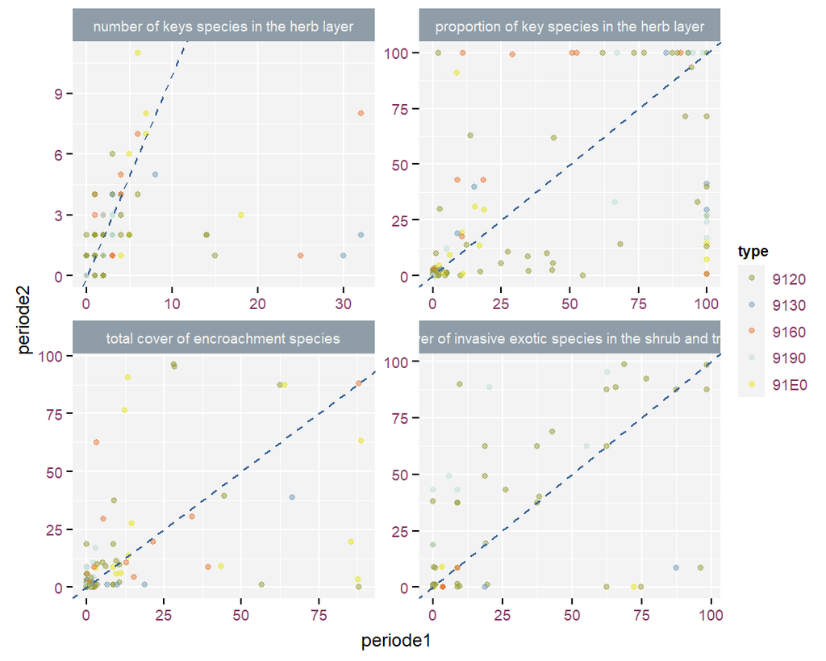

Figuur 3.7: Indicatorwaarden voor de meetpunten van de Vlaamse bosinventarisatie

| habitat type | sample size | indicator | mean difference | standard deviation difference | d | p-value (t-test) | conclusion |
| --- | --- | --- | --- | --- | --- | --- | --- |
| 9120 | 60 | number of keys species in the herb layer | -0.78 | 2.99 | -0.261 | 0.04669 | decrease |
|  |  | proportion of key species in the herb layer | -7.86 | 31.08 | -0.253 | 0.05503 | unknown |
|  |  | total cover of encroachment species | 1.06 | 19.38 | 0.055 | 0.67299 | unknown |
|  |  | total cover of invasive exotic species in the shrub and tree layer | 2.88 | 24.01 | 0.120 | 0.35647 | unknown |
| 91E0 | 15 | number of keys species in the herb layer | -0.93 | 4.33 | -0.215 | 0.41822 | unknown |
|  |  | proportion of key species in the herb layer | -4.44 | 40.58 | -0.109 | 0.67834 | unknown |
|  |  | total cover of encroachment species | -2.28 | 41.47 | -0.055 | 0.83459 | unknown |
|  |  | total cover of invasive exotic species in the shrub and tree layer | -4.45 | 18.81 | -0.237 | 0.37531 | unknown |
| 91xx | 109 | number of keys species in the herb layer | -1.58 | 5.70 | -0.277 | 0.00464 | decrease |
|  |  | proportion of key species in the herb layer | -5.48 | 35.98 | -0.152 | 0.11488 | unknown |
|  |  | total cover of encroachment species | 0.59 | 22.20 | 0.027 | 0.78249 | unknown |
|  |  | total cover of invasive exotic species in the shrub and tree layer | 2.19 | 22.96 | 0.095 | 0.32209 | unknown |

Table 3.8 shows the range of the detectable mean difference for the habitat quality indicators that can be expected for different sample sizes. It is based on the range of observed values for the standard deviation of the indicators as shown in Table 3.7.

Tabel 3.8: Expected range for minimum detectable difference for habitat quality indicators

| indicator | sd of difference | sample size | d | detectable difference |
| --- | --- | --- | --- | --- |
| number of keys species in the herb layer | 2 - 6 | 40 | 0.45 | 0.9 - 2.7 |
|  |  | 80 | 0.32 | 0.6 - 1.9 |
|  |  | 170 | 0.22 | 0.4 - 1.3 |
| proportion of key species in the herb layer | 31 - 41 | 40 | 0.45 | 14 - 18.4 |
|  |  | 80 | 0.32 | 9.9 - 13.1 |
|  |  | 170 | 0.22 | 6.8 - 9 |
| total cover of encroachment species | 19 - 42 | 40 | 0.45 | 8.6 - 18.9 |
|  |  | 80 | 0.32 | 6.1 - 13.4 |
|  |  | 170 | 0.22 | 4.2 - 9.2 |
| total cover of invasive exotic species in the shrub and tree layer | 18 - 25 | 40 | 0.45 | 8.1 - 11.2 |
|  |  | 80 | 0.32 | 5.8 - 8 |
|  |  | 170 | 0.22 | 4 - 5.5 |

# 4 Scenario’s for the design of MHQ

## 4.1 Habitat types and subtypes included in MHQ

An oversampling is considered for all habitat subtypes except for the very rare terrestrial subtypes (defined as habitat subtypes with an area lower than 10 ha or occurring on less than 15 locations). As for dynamic habitat types, we intend to perform a basic habitat quality assessment for very rare terrestrial habitat types and subtypes is combination with the habitat area mapping.

Appendix B shows for which habitat types a monitoring scheme was developed and for which subtypes oversampling is considered. The area and the number of locations (to determine the very rare habitat types and subtypes) is derived from the standardized map of habitat types in Flanders (Westra, Vanderhaeghe, and Herr 2021). This data source is a processed version of the Natura 2000 habitat map (Nature and (INBO) 2020). The standardized map is processed in a way it can be easily imported and analysed in R. It can be imported in R by using the function `read_habitatmap_stdized()` of the n2khab package (Vanderhaeghe et al. 2022).

[output not shown]

## 4.3 Steekproefgroottes terrestrische habitattypen voor verschillende scenario’s

[output not shown]

| type_cat | scenario | n_flanders | n_sac | n_subtype | cycle_years | n_finite_flanders | n_extra_sac | n_extra_subtypes | type_list | n_total | n_total_year |
| --- | --- | --- | --- | --- | --- | --- | --- | --- | --- | --- | --- |
| forest type | original | 80 | 0 | 80 | 12 | 406 | 0 | 548 | 9120, 9130, 9160, 9190, 91E0 | 954 | 80 |
| nonforest type | original | 80 | 170 | 80 | 12 | 1177 | 1403 | 421 | 1330, 2120, 2130, 2160, 2170, 2180, 2190, 2310, 2330, 4010, 4030, 6230, 6410, 6510, 7140 | 3001 | 251 |
|  | alternative 1 | 80 | 80 | 80 | 6 | 1177 | 192 | 649 | 1330, 2120, 2130, 2160, 2170, 2180, 2190, 2310, 2330, 4010, 4030, 6230, 6410, 6510, 7140 | 2018 | 337 |
|  | alternative 2 | 40 | 80 | 40 | 6 | 609 | 673 | 236 | 1330, 2120, 2130, 2160, 2170, 2180, 2190, 2310, 2330, 4010, 4030, 6230, 6410, 6510, 7140 | 1518 | 253 |
|  | alternative 3 | 80 | 80 | 40 | 6 | 1177 | 192 | 194 | 1330, 2120, 2130, 2160, 2170, 2180, 2190, 2310, 2330, 4010, 4030, 6230, 6410, 6510, 7140 | 1563 | 261 |
|  | alternative 4 | 40 | 80 | 80 | 6 | 609 | 673 | 692 | 1330, 2120, 2130, 2160, 2170, 2180, 2190, 2310, 2330, 4010, 4030, 6230, 6410, 6510, 7140 | 1974 | 329 |

## 4.4 Keuze scenario

We kiezen voor de open habitats het scenario alternatief 3. Voor boshabitats behouden we het originele scenario.

# Bibliography

Chow SC, Shao J, Wang H. 2003. *Sample Size Calculation in Clinical Research*. New York: Marcel Dekker.

Cohen, J. 1988. *Statistical Power Analysis for the Behavioral Sciences, 2nd Edition*. Routledge.

DG Environment. 2017. *Reporting Under Article 17 of the Habitats Directive: Explanatory Notes and Guidelines for the Period 2013-2018*. Brussels.

G.Zhang, Ed Zhang ; Vicky Qian Wu ; Shein-Chung Chow ; Harry. 2020. *TrialSize: R Functions for Chapter 3,4,6,7,9,10,11,12,14,15 of Sample Size Calculation in Clinical Research*. https://CRAN.R-project.org/package=TrialSize.

INBO. 2017. *Vegetatie-Opname Met Behulp van de Beheermonitoringschaal. Standaard Veldprotocol SVP-405.* Instituut voor Natuur en Bosonderzoek (INBO).

Nature, Research Institute for, and Forest (INBO). 2020. “Redistribution of the Natura 2000 habitat map of Flanders (version 2020).” Zenodo. https://doi.org/10.5281/zenodo.4428002.

Oosterlynck, Patrik, Steven De Saeger, An Leyssen, Sam Provoost, Arno Thomaes, Bart Vandevoorde, Jan Wouters, and Desiré Paelinckx. 2020. *Criteria Voor de Beoordeling van de Lokale Staat van Instandhouding van de Natura2000 Habitattypen in Vlaanderen: Versie 3.0*. Rapporten van Het Instituut Voor Natuur- En Bosonderzoek 27. België: Instituut voor Natuur- en Bosonderzoek. https://doi.org/10.21436/inbor.14061248.

Paelinckx, Desiré, Steven De Saeger, Patrik Oosterlynck, Jeroen Vanden Borre, Toon Westra, Luc Denys, An Leyssen, et al. 2019. *Regionale Staat van Instandhouding Voor de Habitattypen van de Habitatrichtlijn: Rapportageperiode 2013 - 2018*. Rapporten van Het Instituut Voor Natuur- En Bosonderzoek 13. België: Instituut voor Natuur- en Bosonderzoek. https://doi.org/10.21436/inbor.16122667.

Vanderhaeghe, Floris, Toon Westra, Cécile Herr, and Hans Van Calster. 2022. *R package n2khab: providing preprocessed reference data for Flemish Natura 2000 habitat analyses* (version 0.7.0). Zenodo. https://doi.org/10.5281/zenodo.6574427.

Westra, Toon, Patrik Oosterlynck, Hans Van Calster, Desiré Paelinckx, Luc Denys, An Leyssen, Jo Packet, et al. 2014. *Monitoring Natura 2000-Habitats: Meetnet Habitatkwaliteit*. Rapporten van Het Instituut Voor Natuur- En Bosonderzoek INBO.R.2014.1414229. België: Instituut voor Natuur- en Bosonderzoek.

Westra, Toon, Floris Vanderhaeghe, and Cécile Herr. 2021. “Standardized map of habitat types and regionally important biotopes in Flanders.” Zenodo. https://doi.org/10.5281/zenodo.4912552.

# A Habitat types and subtypes in Flanders

| habitat category | code | habitat type | code_st | habitat subtype |
| --- | --- | --- | --- | --- |
| Coastal and halophytic habitats | 1130 | Estuaries |  |  |
|  | 1140 | Mudflats and sandflats not covered by seawater at low tide |  |  |
|  | 1310 | Salicornia and other annuals colonizing mud and sand | 1310_pol | Salicornia habitats dike inward |
|  |  |  | 1310_zk | Low saltmarshes Salicornia habitats dike outward |
|  |  |  | 1310_zv | High saltmarshes Saginion habitats dike outward |
|  | 1320 | Spartina swards (Spartinion maritimae) |  |  |
|  | 1330 | Atlantic salt meadows (Glauco-Puccinellietalia maritimae) | 1330_da | Saltmarshes dike outward |
|  |  |  | 1330_hpr | Halophytic grasslands dike inward |
| Coastal sand dunes | 2110 | Embryonic shifting dunes |  |  |
|  | 2120 | Shifting dunes along the shoreline with Ammophila arenaria (“white dunes”) |  |  |
|  | 2130 | Fixed coastal dunes with herbaceous vegetation (“grey dunes”) | 2130_had | Decalcified dune grasslands |
|  |  |  | 2130_hd | Calcareous dune grasslands |
|  | 2150 | Atlantic decalcified fixed dunes (Calluno-Ulicetea) |  |  |
|  | 2160 | Dunes with Hippophaë rhamnoides |  |  |
|  | 2170 | Dunes with Salix repens ssp. argentea (Salicion arenariae) |  |  |
|  | 2180 | Wooded dunes of the Atlantic, Continental and Boreal region |  |  |
|  | 2190 | Humid dune slacks | 2190_a | Dune slack ponds |
|  |  |  | 2190_mp | Calcareous dune slacks |
|  |  |  | 2190_overig | Other dune slacks |
| Inland dunes | 2310 | Dry sand heaths with Calluna and Genista |  |  |
|  | 2330 | Inland dunes with open Corynephorus and Agrostis grasslands | 2330_bu | Inland dunes with Corynephorus |
|  |  |  | 2330_dw | Inland dunes with Aira |
| Fresh and brackish water | 3110 | Oligotrophic waters containing very few minerals of sandy plains (Littorelletalia uniflorae) |  |  |
|  | 3130 | Oligotrophic to mesotrophic standing waters with vegetation of the Littorelletea uniflorae and/or of the Isoëto-Nanojuncetea | 3130_aom | Oligotrophic to mesotrophic standing waters with vegetation of the Littorelletea uniflorae |
|  |  |  | 3130_na | Oligotrophic to mesotrophic standing waters with vegetation of the Isoëto-Nanojuncetea |
|  | 3140 | Hard oligo-mesotrophic waters with benthic vegetation of Chara spp. |  |  |
|  | 3150 | Natural eutrophic lakes with Magnopotamion or Hydrocharition - type vegetation |  |  |
|  | 3160 | Natural dystrophic lakes and ponds |  |  |
|  | 3260 | Water courses of plain to montane levels with the Ranunculion fluitantis and Callitricho-Batrachion vegetation |  |  |
|  | 3270 | Rivers with muddy banks with Chenopodion rubri p.p. and Bidention p.p. vegetation |  |  |

[output cut: 62 more lines]

# B Habitat types and subtypes included in MHQ

Tabel B.1: Selection of the habitat types for which a monitoring scheme is implemented

| code habitat type | area (ha) | # locations | monitoring scheme | reason |
| --- | --- | --- | --- | --- |
| 1130 | 5680 | 4413 | no | habitat quality evaluation on landsacpe scale |
| 1140 | 2096 | 46 | no | no habitat quality indicators available |
| 1310 | 57 | 238 | no | very dynamic habitat type |
| 1320 | 2 | 49 | no | very rare terrestrial type |
| 1330 | 251 | 1264 | yes |  |
| 2110 | 27 | 290 | no | very dynamic habitat type |
| 2120 | 446 | 415 | yes |  |
| 2130 | 802 | 1236 | yes |  |
| 2160 | 645 | 1041 | yes |  |
| 2170 | 63 | 196 | yes |  |
| 2180 | 245 | 195 | yes |  |
| 2190 | 56 | 273 | yes |  |
| 2310 | 2430 | 2110 | yes |  |
| 2330 | 1077 | 1201 | yes |  |
| 3110 | 2 | 3 | yes |  |
| 3130 | 1192 | 1564 | yes |  |
| 3140 | 542 | 94 | yes |  |
| 3150 | 478 | 444 | yes |  |
| 3160 | 192 | 363 | yes |  |
| 3260 | 278 | 319 | yes |  |
| 3270 | 27 | 51 | no | very dynamic habitat type |
| 4010 | 1853 | 2848 | yes |  |
| 4030 | 4381 | 4269 | yes |  |
| 5130 | 26 | 14 | no | very rare terrestrial type |
| 6120 | 13 | 18 | no |  |
| 6210 | 4 | 18 | no | very rare terrestrial type |
| 6230 | 718 | 1756 | yes |  |
| 6410 | 73 | 257 | yes |  |
| 6430 | 1423 | 2839 | no | no accurate sample frame |
| 6510 | 3182 | 4925 | yes |  |
| 7110 | 2 | 1 | no | very rare terrestrial type |
| 7140 | 300 | 783 | yes |  |
| 7150 | 41 | 205 | no | very dynamic habitat type |
| 7210 | 2 | 15 | no | very rare terrestrial type |
| 7230 | 10 | 24 | no | very rare terrestrial type |
| 9110 | 360 | 241 | no | low priority |
| 9120 | 18585 | 12279 | yes |  |
| 9130 | 3350 | 2788 | yes |  |
| 9150 | 3 | 11 | no | very rare terrestrial type |
| 9160 | 3600 | 4124 | yes |  |
| 9190 | 3895 | 3092 | yes |  |
| 91E0 | 11159 | 14783 | yes |  |
| 91F0 | 1 | 1 | no | very rare terrestrial type |

Tabel B.2: Oversampling habitat subtypes

| code type | code subtype | area (ha) | # locations | oversampling | reason |
| --- | --- | --- | --- | --- | --- |
| 1330 | 1330_da | 117 | 637 | yes |  |
|  | 1330_hpr | 134 | 627 | yes |  |
| 2130 | 2130_had | 125 | 41 | yes |  |
|  | 2130_hd | 678 | 1195 | yes |  |
| 2190 | 2190_mp | 8 | 50 | no | very rare terrestrtial subtype |
| 2330 | 2330_bu | 925 | 862 | yes |  |
|  | 2330_dw | 116 | 262 | yes |  |
| 3130 | 3130_aom | 483 | 994 | yes |  |
|  | 3130_na | 637 | 352 | yes |  |
| 6230 | 6230_ha | 239 | 612 | yes |  |
|  | 6230_hmo | 146 | 412 | yes |  |
|  | 6230_hn | 277 | 602 | yes |  |
|  | 6230_hnk | 4 | 20 | no | very rare terrestrtial subtype |
| 6410 | 6410_mo | 41 | 168 | yes |  |
|  | 6410_ve | 2 | 7 | no | very rare terrestrtial subtype |
| 6510 | 6510_hu | 1609 | 2571 | yes |  |
|  | 6510_hua | 111 | 69 | yes |  |
|  | 6510_huk | 60 | 199 | yes |  |
|  | 6510_hus | 15 | 34 | yes |  |
| 7140 | 7140_base | 1 | 6 | no | very rare terrestrtial subtype |
|  | 7140_meso | 177 | 536 | yes |  |
|  | 7140_mrd | 8 | 21 | no | very rare terrestrtial subtype |
|  | 7140_oli | 94 | 149 | yes |  |
| 9120 | 9120_qb | 673 | 623 | yes |  |
| 9130 | 9130_end | 3203 | 2604 | yes |  |
|  | 9130_fm | 49 | 50 | yes |  |
| 91E0 | 91E0_sf | 346 | 610 | yes |  |
|  | 91E0_va | 3960 | 5540 | yes |  |
|  | 91E0_vc | 341 | 767 | yes |  |
|  | 91E0_vm | 2955 | 3461 | yes |  |
|  | 91E0_vn | 2776 | 3287 | yes |  |
|  | 91E0_vo | 523 | 856 | yes |  |